# LeBron James: The Offensive Evolution in the NBA

# Questions

- Shot selection: how has LeBron's shot selection evolved over the years? Has he changed the types of shots he takes, such as moving from mid-range to three-point shots?
- Efficiency: how has LeBron's shooting efficiency evolved over the years? Has he become a more efficient scorer?
- Impact on team performance: how has LeBron's offensive evolution influenced the performance of his teams? Has he been able to improve the offensive production of his teams over the years?

# Datasets

- LeBron James Career Attempts: [EDU VADILLO's Kaggle dataset](https://www.kaggle.com/datasets/eduvadillo/lebron-james-career-shots)
- LeBron James Career Advanced Stats: [basketball-reference.com](https://www.basketball-reference.com/players/j/jamesle01.html#advanced) and [statmuse.com](https://www.statmuse.com/nba/ask/nba)

# Shot selection

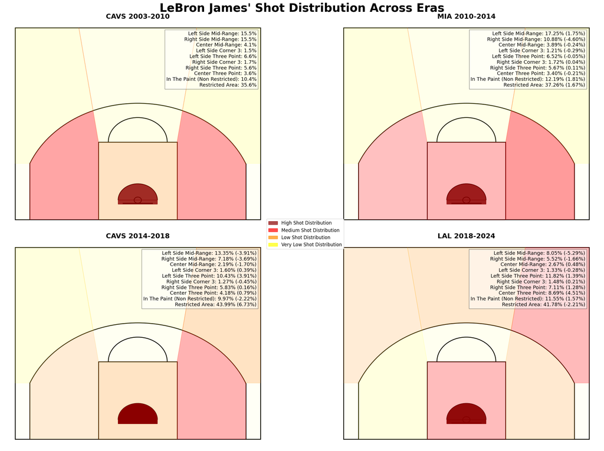

# Efficiency

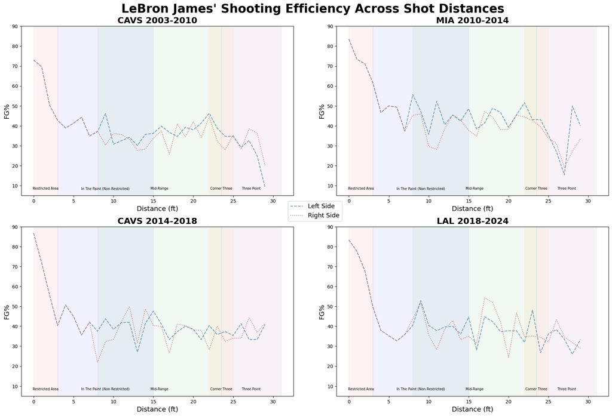

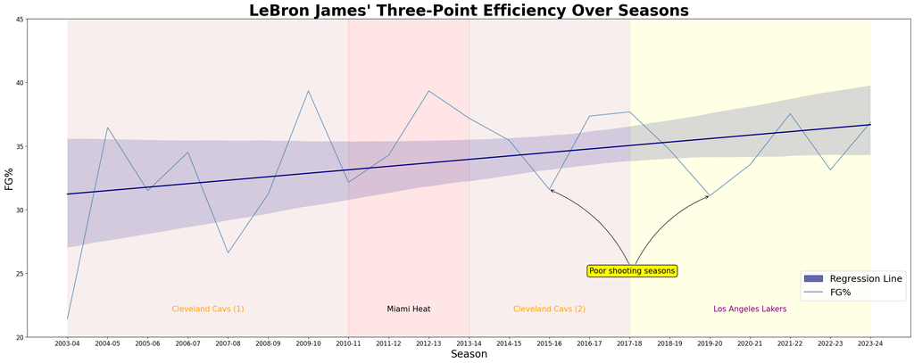

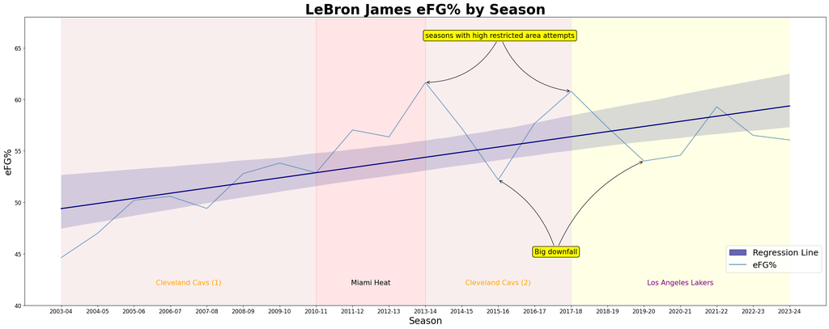